# R Notebook

```r
df <- read.csv('mxmh_survey_results.csv')
print(df)
```

| Timestamp | Age | Primary.streaming.service | Hours.per.day | While.working | Instrumentalist | Composer | Fav.genre | Exploratory | Foreign.languages | BPM | Frequency..Classical. | Frequency..Country. | Frequency..EDM. | Frequency..Folk. | Frequency..Gospel. | Frequency..Hip.hop. | Frequency..Jazz. | Frequency..K.pop. | Frequency..Latin. | Frequency..Lofi. | Frequency..Metal. | Frequency..Pop. | Frequency..R.B. | Frequency..Rap. | Frequency..Rock. | Frequency..Video.game.music. | Anxiety | Depression | Insomnia | … |
| --- | --- | --- | --- | --- | --- | --- | --- | --- | --- | --- | --- | --- | --- | --- | --- | --- | --- | --- | --- | --- | --- | --- | --- | --- | --- | --- | --- | --- | --- | --- |
| 8/27/2022 19:29:02 | 18 | Spotify | 3.00 | Yes | Yes | Yes | Latin | Yes | Yes | 156 | Rarely | Never | Rarely | Never | Never | Sometimes | Never | Very frequently | Very frequently | Rarely | Never | Very frequently | Sometimes | Very frequently | Never | Sometimes | 3.0 | 0.0 | 1.0 | … |
| 8/27/2022 19:57:31 | 63 | Pandora | 1.50 | Yes | No | No | Rock | Yes | No | 119 | Sometimes | Never | Never | Rarely | Sometimes | Rarely | Very frequently | Rarely | Sometimes | Rarely | Never | Sometimes | Sometimes | Rarely | Very frequently | Rarely | 7.0 | 2.0 | 2.0 | … |
| 8/27/2022 21:28:18 | 18 | Spotify | 4.00 | No | No | No | Video game music | No | Yes | 132 | Never | Never | Very frequently | Never | Never | Rarely | Rarely | Very frequently | Never | Sometimes | Sometimes | Rarely | Never | Rarely | Rarely | Very frequently | 7.0 | 7.0 | 10.0 | … |
| 8/27/2022 21:40:40 | 61 | YouTube Music | 2.50 | Yes | No | Yes | Jazz | Yes | Yes | 84 | Sometimes | Never | Never | Rarely | Sometimes | Never | Very frequently | Sometimes | Very frequently | Sometimes | Never | Sometimes | Sometimes | Never | Never | Never | 9.0 | 7.0 | 3.0 | … |
| 8/27/2022 21:54:47 | 18 | Spotify | 4.00 | Yes | No | No | R&B | Yes | No | 107 | Never | Never | Rarely | Never | Rarely | Very frequently | Never | Very frequently | Sometimes | Sometimes | Never | Sometimes | Very frequently | Very frequently | Never | Rarely | 7.0 | 2.0 | 5.0 | … |
| 8/27/2022 21:56:50 | 18 | Spotify | 5.00 | Yes | Yes | Yes | Jazz | Yes | Yes | 86 | Rarely | Sometimes | Never | Never | Never | Sometimes | Very frequently | Very frequently | Rarely | Very frequently | Rarely | Very frequently | Very frequently | Very frequently | Very frequently | Never | 8.0 | 8.0 | 7.0 | … |
| 8/27/2022 22:00:29 | 18 | YouTube Music | 3.00 | Yes | Yes | No | Video game music | Yes | Yes | 66 | Sometimes | Never | Rarely | Sometimes | Rarely | Rarely | Sometimes | Never | Rarely | Rarely | Rarely | Rarely | Rarely | Never | Never | Sometimes | 4.0 | 8.0 | 6.0 | … |
| 8/27/2022 22:18:59 | 21 | Spotify | 1.00 | Yes | No | No | K pop | Yes | Yes | 95 | Never | Never | Rarely | Never | Never | Very frequently | Rarely | Very frequently | Never | Sometimes | Never | Sometimes | Sometimes | Rarely | Never | Rarely | 5.0 | 3.0 | 5.0 | … |
| 8/27/2022 22:33:05 | 19 | Spotify | 6.00 | Yes | No | No | Rock | No | No | 94 | Never | Very frequently | Never | Sometimes | Never | Never | Never | Never | Never | Never | Very frequently | Never | Never | Never | Very frequently | Never | 2.0 | 0.0 | 0.0 | … |
| 8/27/2022 22:44:03 | 18 | I do not use a streaming service. | 1.00 | Yes | No | No | R&B | Yes | Yes | 155 | Rarely | Rarely | Rarely | Rarely | Sometimes | Rarely | Rarely | Never | Rarely | Rarely | Never | Sometimes | Sometimes | Rarely | Sometimes | Sometimes | 2.0 | 2.0 | 5.0 | … |

[output cut: 726 more lines]

```r
names (df)
```

```
 [1] "Timestamp"                    "Age"                          "Primary.streaming.service"    "Hours.per.day"
 [5] "While.working"                "Instrumentalist"              "Composer"                     "Fav.genre"
 [9] "Exploratory"                  "Foreign.languages"            "BPM"                          "Frequency..Classical."
[13] "Frequency..Country."          "Frequency..EDM."              "Frequency..Folk."             "Frequency..Gospel."
[17] "Frequency..Hip.hop."          "Frequency..Jazz."             "Frequency..K.pop."            "Frequency..Latin."
[21] "Frequency..Lofi."             "Frequency..Metal."            "Frequency..Pop."              "Frequency..R.B."
[25] "Frequency..Rap."              "Frequency..Rock."             "Frequency..Video.game.music." "Anxiety"
[29] "Depression"                   "Insomnia"                     "OCD"                          "Music.effects"
[33] "Permissions"
```

```r
# Renaming frequency features for a simpler data manipulation

names(df)[12:27] <- c("FClassical", "FCountry", "FEDM", "FFolk", "FGospel", "FHipHop",
                      "FJazz", "FKpop", "FLatin", "FLofi", "FMetal", "FPop",
                      "FRnB", "FRap", "FRock", "FVGM")


print(names(df))
```

```
 [1] "Timestamp"                 "Age"                       "Primary.streaming.service" "Hours.per.day"             "While.working"
 [6] "Instrumentalist"           "Composer"                  "Fav.genre"                 "Exploratory"               "Foreign.languages"
[11] "BPM"                       "FClassical"                "FCountry"                  "FEDM"                      "FFolk"
[16] "FGospel"                   "FHipHop"                   "FJazz"                     "FKpop"                     "FLatin"
[21] "FLofi"                     "FMetal"                    "FPop"                      "FRnB"                      "FRap"
[26] "FRock"                     "FVGM"                      "Anxiety"                   "Depression"                "Insomnia"
[31] "OCD"                       "Music.effects"             "Permissions"
```

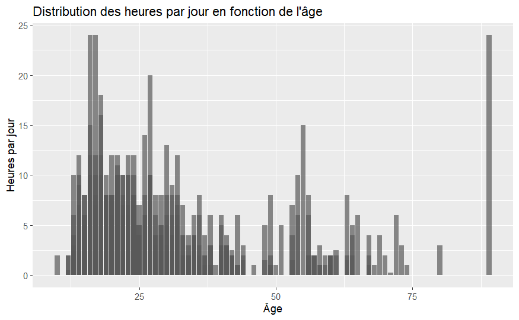

```r
library(ggplot2)
ggplot(df, aes(x = Age, y = Hours.per.day )) +
  geom_bar(stat = "identity", position = "dodge", alpha = 0.7) +
  labs(title = "Distribution des heures par jour en fonction de l'âge",
       x = "Âge",
       y = "Heures par jour")
```

# CLEANING THE DATA

## Removing illogical values:

```r
df <- subset(df, `Hours.per.day` != 24)
print(df)
```

|  | Timestamp | Age | Primary.streaming.service | Hours.per.day | While.working | Instrumentalist | Composer | Fav.genre | Exploratory | Foreign.languages | BPM | FClassical | FCountry | FEDM | FFolk | FGospel | FHipHop | FJazz | FKpop | FLatin | FLofi | FMetal | FPop | FRnB | FRap | FRock | FVGM | Anxiety | Depression | … |
| --- | --- | --- | --- | --- | --- | --- | --- | --- | --- | --- | --- | --- | --- | --- | --- | --- | --- | --- | --- | --- | --- | --- | --- | --- | --- | --- | --- | --- | --- | --- |
| 1 | 8/27/2022 19:29:02 | 18 | Spotify | 3.00 | Yes | Yes | Yes | Latin | Yes | Yes | 156 | Rarely | Never | Rarely | Never | Never | Sometimes | Never | Very frequently | Very frequently | Rarely | Never | Very frequently | Sometimes | Very frequently | Never | Sometimes | 3.0 | 0.0 | … |
| 2 | 8/27/2022 19:57:31 | 63 | Pandora | 1.50 | Yes | No | No | Rock | Yes | No | 119 | Sometimes | Never | Never | Rarely | Sometimes | Rarely | Very frequently | Rarely | Sometimes | Rarely | Never | Sometimes | Sometimes | Rarely | Very frequently | Rarely | 7.0 | 2.0 | … |
| 3 | 8/27/2022 21:28:18 | 18 | Spotify | 4.00 | No | No | No | Video game music | No | Yes | 132 | Never | Never | Very frequently | Never | Never | Rarely | Rarely | Very frequently | Never | Sometimes | Sometimes | Rarely | Never | Rarely | Rarely | Very frequently | 7.0 | 7.0 | … |
| 4 | 8/27/2022 21:40:40 | 61 | YouTube Music | 2.50 | Yes | No | Yes | Jazz | Yes | Yes | 84 | Sometimes | Never | Never | Rarely | Sometimes | Never | Very frequently | Sometimes | Very frequently | Sometimes | Never | Sometimes | Sometimes | Never | Never | Never | 9.0 | 7.0 | … |
| 5 | 8/27/2022 21:54:47 | 18 | Spotify | 4.00 | Yes | No | No | R&B | Yes | No | 107 | Never | Never | Rarely | Never | Rarely | Very frequently | Never | Very frequently | Sometimes | Sometimes | Never | Sometimes | Very frequently | Very frequently | Never | Rarely | 7.0 | 2.0 | … |
| 6 | 8/27/2022 21:56:50 | 18 | Spotify | 5.00 | Yes | Yes | Yes | Jazz | Yes | Yes | 86 | Rarely | Sometimes | Never | Never | Never | Sometimes | Very frequently | Very frequently | Rarely | Very frequently | Rarely | Very frequently | Very frequently | Very frequently | Very frequently | Never | 8.0 | 8.0 | … |
| 7 | 8/27/2022 22:00:29 | 18 | YouTube Music | 3.00 | Yes | Yes | No | Video game music | Yes | Yes | 66 | Sometimes | Never | Rarely | Sometimes | Rarely | Rarely | Sometimes | Never | Rarely | Rarely | Rarely | Rarely | Rarely | Never | Never | Sometimes | 4.0 | 8.0 | … |
| 8 | 8/27/2022 22:18:59 | 21 | Spotify | 1.00 | Yes | No | No | K pop | Yes | Yes | 95 | Never | Never | Rarely | Never | Never | Very frequently | Rarely | Very frequently | Never | Sometimes | Never | Sometimes | Sometimes | Rarely | Never | Rarely | 5.0 | 3.0 | … |
| 9 | 8/27/2022 22:33:05 | 19 | Spotify | 6.00 | Yes | No | No | Rock | No | No | 94 | Never | Very frequently | Never | Sometimes | Never | Never | Never | Never | Never | Never | Very frequently | Never | Never | Never | Very frequently | Never | 2.0 | 0.0 | … |
| 10 | 8/27/2022 22:44:03 | 18 | I do not use a streaming service. | 1.00 | Yes | No | No | R&B | Yes | Yes | 155 | Rarely | Rarely | Rarely | Rarely | Sometimes | Rarely | Rarely | Never | Rarely | Rarely | Never | Sometimes | Sometimes | Rarely | Sometimes | Sometimes | 2.0 | 2.0 | … |

[output cut: 723 more lines]

```r
NA
```

## Removing unuseful data

```r
#removing unuseful data
df <- df[, -which(names(df) == "Timestamp")]
df <- df[, -which(names(df) == "Permissions")]

df <- df[ df$`Music.effects` != '', ]
print(df)
```

|  | Age | Primary.streaming.service | Hours.per.day | While.working | Instrumentalist | Composer | Fav.genre | Exploratory | Foreign.languages | BPM | FClassical | FCountry | FEDM | FFolk | FGospel | FHipHop | FJazz | FKpop | FLatin | FLofi | FMetal | FPop | FRnB | FRap | FRock | FVGM | Anxiety | Depression | Insomnia | … |
| --- | --- | --- | --- | --- | --- | --- | --- | --- | --- | --- | --- | --- | --- | --- | --- | --- | --- | --- | --- | --- | --- | --- | --- | --- | --- | --- | --- | --- | --- | --- |
| 3 | 18 | Spotify | 4.00 | No | No | No | Video game music | No | Yes | 132 | Never | Never | Very frequently | Never | Never | Rarely | Rarely | Very frequently | Never | Sometimes | Sometimes | Rarely | Never | Rarely | Rarely | Very frequently | 7.0 | 7.0 | 10.0 | … |
| 4 | 61 | YouTube Music | 2.50 | Yes | No | Yes | Jazz | Yes | Yes | 84 | Sometimes | Never | Never | Rarely | Sometimes | Never | Very frequently | Sometimes | Very frequently | Sometimes | Never | Sometimes | Sometimes | Never | Never | Never | 9.0 | 7.0 | 3.0 | … |
| 5 | 18 | Spotify | 4.00 | Yes | No | No | R&B | Yes | No | 107 | Never | Never | Rarely | Never | Rarely | Very frequently | Never | Very frequently | Sometimes | Sometimes | Never | Sometimes | Very frequently | Very frequently | Never | Rarely | 7.0 | 2.0 | 5.0 | … |
| 6 | 18 | Spotify | 5.00 | Yes | Yes | Yes | Jazz | Yes | Yes | 86 | Rarely | Sometimes | Never | Never | Never | Sometimes | Very frequently | Very frequently | Rarely | Very frequently | Rarely | Very frequently | Very frequently | Very frequently | Very frequently | Never | 8.0 | 8.0 | 7.0 | … |
| 7 | 18 | YouTube Music | 3.00 | Yes | Yes | No | Video game music | Yes | Yes | 66 | Sometimes | Never | Rarely | Sometimes | Rarely | Rarely | Sometimes | Never | Rarely | Rarely | Rarely | Rarely | Rarely | Never | Never | Sometimes | 4.0 | 8.0 | 6.0 | … |
| 8 | 21 | Spotify | 1.00 | Yes | No | No | K pop | Yes | Yes | 95 | Never | Never | Rarely | Never | Never | Very frequently | Rarely | Very frequently | Never | Sometimes | Never | Sometimes | Sometimes | Rarely | Never | Rarely | 5.0 | 3.0 | 5.0 | … |
| 9 | 19 | Spotify | 6.00 | Yes | No | No | Rock | No | No | 94 | Never | Very frequently | Never | Sometimes | Never | Never | Never | Never | Never | Never | Very frequently | Never | Never | Never | Very frequently | Never | 2.0 | 0.0 | 0.0 | … |
| 10 | 18 | I do not use a streaming service. | 1.00 | Yes | No | No | R&B | Yes | Yes | 155 | Rarely | Rarely | Rarely | Rarely | Sometimes | Rarely | Rarely | Never | Rarely | Rarely | Never | Sometimes | Sometimes | Rarely | Sometimes | Sometimes | 2.0 | 2.0 | 5.0 | … |
| 11 | 18 | Spotify | 3.00 | Yes | Yes | No | Country | Yes | No | NA | Never | Very frequently | Never | Never | Never | Never | Never | Never | Never | Never | Never | Rarely | Rarely | Never | Rarely | Never | 7.0 | 7.0 | 4.0 | … |
| 12 | 19 | YouTube Music | 8.00 | Yes | No | No | EDM | Yes | No | 125 | Rarely | Never | Very frequently | Never | Never | Sometimes | Rarely | Rarely | Rarely | Rarely | Never | Rarely | Rarely | Sometimes | Rarely | Rarely | 1.0 | 0.0 | 0.0 | … |

[output cut: 715 more lines]

```r
df <- subset(df, !is.na(Age))

print (df)
```

|  | Age | Primary.streaming.service | Hours.per.day | While.working | Instrumentalist | Composer | Fav.genre | Exploratory | Foreign.languages | BPM | FClassical | FCountry | FEDM | FFolk | FGospel | FHipHop | FJazz | FKpop | FLatin | FLofi | FMetal | FPop | FRnB | FRap | FRock | FVGM | Anxiety | Depression | Insomnia | … |
| --- | --- | --- | --- | --- | --- | --- | --- | --- | --- | --- | --- | --- | --- | --- | --- | --- | --- | --- | --- | --- | --- | --- | --- | --- | --- | --- | --- | --- | --- | --- |
| 3 | 18 | Spotify | 4.00 | No | No | No | Video game music | No | Yes | 132 | Never | Never | Very frequently | Never | Never | Rarely | Rarely | Very frequently | Never | Sometimes | Sometimes | Rarely | Never | Rarely | Rarely | Very frequently | 7.0 | 7.0 | 10.0 | … |
| 4 | 61 | YouTube Music | 2.50 | Yes | No | Yes | Jazz | Yes | Yes | 84 | Sometimes | Never | Never | Rarely | Sometimes | Never | Very frequently | Sometimes | Very frequently | Sometimes | Never | Sometimes | Sometimes | Never | Never | Never | 9.0 | 7.0 | 3.0 | … |
| 5 | 18 | Spotify | 4.00 | Yes | No | No | R&B | Yes | No | 107 | Never | Never | Rarely | Never | Rarely | Very frequently | Never | Very frequently | Sometimes | Sometimes | Never | Sometimes | Very frequently | Very frequently | Never | Rarely | 7.0 | 2.0 | 5.0 | … |
| 6 | 18 | Spotify | 5.00 | Yes | Yes | Yes | Jazz | Yes | Yes | 86 | Rarely | Sometimes | Never | Never | Never | Sometimes | Very frequently | Very frequently | Rarely | Very frequently | Rarely | Very frequently | Very frequently | Very frequently | Very frequently | Never | 8.0 | 8.0 | 7.0 | … |
| 7 | 18 | YouTube Music | 3.00 | Yes | Yes | No | Video game music | Yes | Yes | 66 | Sometimes | Never | Rarely | Sometimes | Rarely | Rarely | Sometimes | Never | Rarely | Rarely | Rarely | Rarely | Rarely | Never | Never | Sometimes | 4.0 | 8.0 | 6.0 | … |
| 8 | 21 | Spotify | 1.00 | Yes | No | No | K pop | Yes | Yes | 95 | Never | Never | Rarely | Never | Never | Very frequently | Rarely | Very frequently | Never | Sometimes | Never | Sometimes | Sometimes | Rarely | Never | Rarely | 5.0 | 3.0 | 5.0 | … |
| 9 | 19 | Spotify | 6.00 | Yes | No | No | Rock | No | No | 94 | Never | Very frequently | Never | Sometimes | Never | Never | Never | Never | Never | Never | Very frequently | Never | Never | Never | Very frequently | Never | 2.0 | 0.0 | 0.0 | … |
| 10 | 18 | I do not use a streaming service. | 1.00 | Yes | No | No | R&B | Yes | Yes | 155 | Rarely | Rarely | Rarely | Rarely | Sometimes | Rarely | Rarely | Never | Rarely | Rarely | Never | Sometimes | Sometimes | Rarely | Sometimes | Sometimes | 2.0 | 2.0 | 5.0 | … |
| 11 | 18 | Spotify | 3.00 | Yes | Yes | No | Country | Yes | No | NA | Never | Very frequently | Never | Never | Never | Never | Never | Never | Never | Never | Never | Rarely | Rarely | Never | Rarely | Never | 7.0 | 7.0 | 4.0 | … |
| 12 | 19 | YouTube Music | 8.00 | Yes | No | No | EDM | Yes | No | 125 | Rarely | Never | Very frequently | Never | Never | Sometimes | Rarely | Rarely | Rarely | Rarely | Never | Rarely | Rarely | Sometimes | Rarely | Rarely | 1.0 | 0.0 | 0.0 | … |

[output cut: 714 more lines]

```r
NA
```

```r
# Compter le nombre de valeurs NaN dans la colonne 'Hours.per.day'
na_count <- sum(is.na(df))

# Afficher le nombre de valeurs NaN
print(na_count)
```

```
[1] 103
```

```r
df <- subset(df, select = -BPM)
df
```

|  | Age | Primary.streaming.service | Hours.per.day | While.working | Instrumentalist | Composer | Fav.genre | Exploratory | Foreign.languages | FClassical | FCountry | FEDM | FFolk | FGospel | FHipHop | FJazz | FKpop | FLatin | FLofi | FMetal | FPop | FRnB | FRap | FRock | FVGM | Anxiety | Depression | Insomnia | OCD | … |
| --- | --- | --- | --- | --- | --- | --- | --- | --- | --- | --- | --- | --- | --- | --- | --- | --- | --- | --- | --- | --- | --- | --- | --- | --- | --- | --- | --- | --- | --- | --- |
| 3 | 18 | Spotify | 4.00 | No | No | No | Video game music | No | Yes | Never | Never | Very frequently | Never | Never | Rarely | Rarely | Very frequently | Never | Sometimes | Sometimes | Rarely | Never | Rarely | Rarely | Very frequently | 7.0 | 7.0 | 10.0 | 2.0 | … |
| 4 | 61 | YouTube Music | 2.50 | Yes | No | Yes | Jazz | Yes | Yes | Sometimes | Never | Never | Rarely | Sometimes | Never | Very frequently | Sometimes | Very frequently | Sometimes | Never | Sometimes | Sometimes | Never | Never | Never | 9.0 | 7.0 | 3.0 | 3.0 | … |
| 5 | 18 | Spotify | 4.00 | Yes | No | No | R&B | Yes | No | Never | Never | Rarely | Never | Rarely | Very frequently | Never | Very frequently | Sometimes | Sometimes | Never | Sometimes | Very frequently | Very frequently | Never | Rarely | 7.0 | 2.0 | 5.0 | 9.0 | … |
| 6 | 18 | Spotify | 5.00 | Yes | Yes | Yes | Jazz | Yes | Yes | Rarely | Sometimes | Never | Never | Never | Sometimes | Very frequently | Very frequently | Rarely | Very frequently | Rarely | Very frequently | Very frequently | Very frequently | Very frequently | Never | 8.0 | 8.0 | 7.0 | 7.0 | … |
| 7 | 18 | YouTube Music | 3.00 | Yes | Yes | No | Video game music | Yes | Yes | Sometimes | Never | Rarely | Sometimes | Rarely | Rarely | Sometimes | Never | Rarely | Rarely | Rarely | Rarely | Rarely | Never | Never | Sometimes | 4.0 | 8.0 | 6.0 | 0.0 | … |
| 8 | 21 | Spotify | 1.00 | Yes | No | No | K pop | Yes | Yes | Never | Never | Rarely | Never | Never | Very frequently | Rarely | Very frequently | Never | Sometimes | Never | Sometimes | Sometimes | Rarely | Never | Rarely | 5.0 | 3.0 | 5.0 | 3.0 | … |
| 9 | 19 | Spotify | 6.00 | Yes | No | No | Rock | No | No | Never | Very frequently | Never | Sometimes | Never | Never | Never | Never | Never | Never | Very frequently | Never | Never | Never | Very frequently | Never | 2.0 | 0.0 | 0.0 | 0.0 | … |
| 10 | 18 | I do not use a streaming service. | 1.00 | Yes | No | No | R&B | Yes | Yes | Rarely | Rarely | Rarely | Rarely | Sometimes | Rarely | Rarely | Never | Rarely | Rarely | Never | Sometimes | Sometimes | Rarely | Sometimes | Sometimes | 2.0 | 2.0 | 5.0 | 1.0 | … |
| 11 | 18 | Spotify | 3.00 | Yes | Yes | No | Country | Yes | No | Never | Very frequently | Never | Never | Never | Never | Never | Never | Never | Never | Never | Rarely | Rarely | Never | Rarely | Never | 7.0 | 7.0 | 4.0 | 7.0 | … |
| 12 | 19 | YouTube Music | 8.00 | Yes | No | No | EDM | Yes | No | Rarely | Never | Very frequently | Never | Never | Sometimes | Rarely | Rarely | Rarely | Rarely | Never | Rarely | Rarely | Sometimes | Rarely | Rarely | 1.0 | 0.0 | 0.0 | 1.0 | … |

[output cut: 714 more lines]

# Visualizing our data:

```r
max_age <- max(df$Age, na.rm = TRUE)

df$Age_Group <- cut(df$Age, breaks = seq(0, max_age + 10, by = 10))

print(names(df))
```

```
 [1] "Age"                       "Primary.streaming.service" "Hours.per.day"             "While.working"             "Instrumentalist"
 [6] "Composer"                  "Fav.genre"                 "Exploratory"               "Foreign.languages"         "FClassical"
[11] "FCountry"                  "FEDM"                      "FFolk"                     "FGospel"                   "FHipHop"
[16] "FJazz"                     "FKpop"                     "FLatin"                    "FLofi"                     "FMetal"
[21] "FPop"                      "FRnB"                      "FRap"                      "FRock"                     "FVGM"
[26] "Anxiety"                   "Depression"                "Insomnia"                  "OCD"                       "Music.effects"
[31] "Age_Group"
```

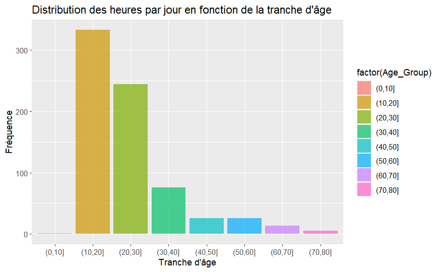

```r
ggplot(df, aes(x = factor(Age_Group), fill = factor(Age_Group))) +
  geom_bar(stat = "count", position = "dodge", alpha = 0.7) +
  labs(title = "Distribution des heures par jour en fonction de la tranche d'âge",
       x = "Tranche d'âge",
       y = "Fréquence")
```

Based on this data, it’s evident that the age groups most frequently engaged in listening to music are predominantly between 10 and 30 years old.

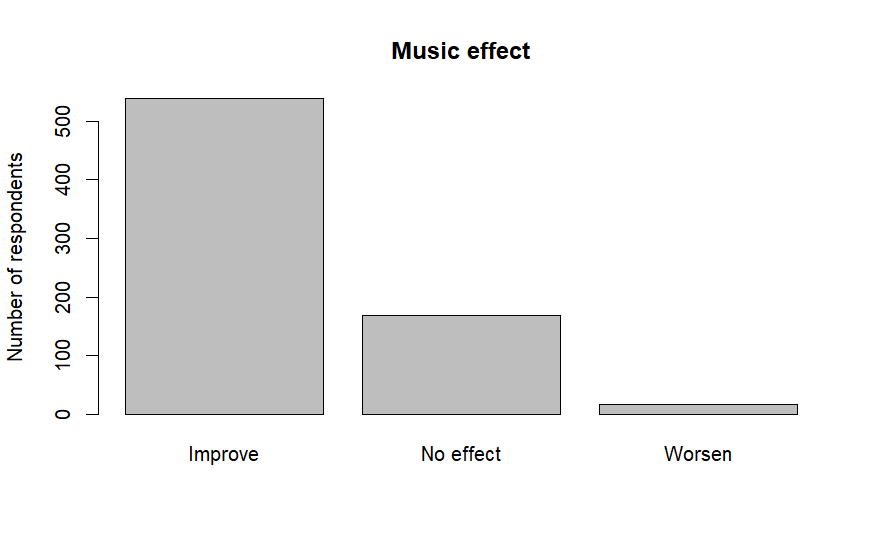

```r
effect_counts <- table(df$`Music.effects`)

# Tracer un graphique à barres
barplot(effect_counts,
        main = "Music effect",
        ylab = "Number of respondents")
```

This figure illustrates that the majority of individuals reported an improvement in their mental health due to music, with very few indicating that it worsened them.

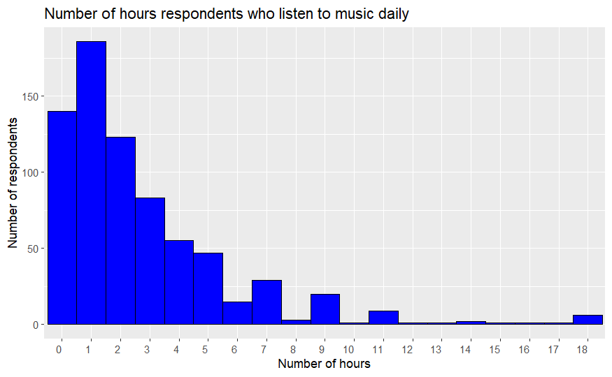

```r
# Créer des intervalles personnalisés pour couvrir toutes les heures de 0 à 24
custom_intervals <- seq(0, 24, by = 1)

# Tracer un graphique à barres avec des intervalles personnalisés
ggplot(df, aes(x = cut(`Hours.per.day`, breaks = custom_intervals))) +
  geom_bar(width = 1, color = "black", fill = "blue") +
  labs(x = "Number of hours", y = "Number of respondents", title = "Number of hours respondents who listen to music daily") +
  scale_x_discrete(labels = custom_intervals) +
  theme(axis.text.x = element_text(angle = 0, hjust = 1))
```

The data indicates that a significant portion of respondents reported listening to music for durations ranging between 1 and 2 hours.

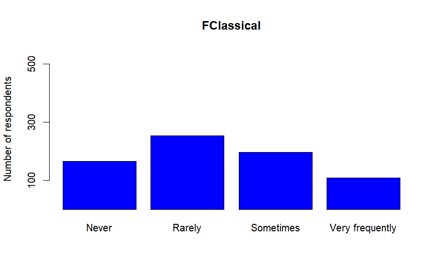

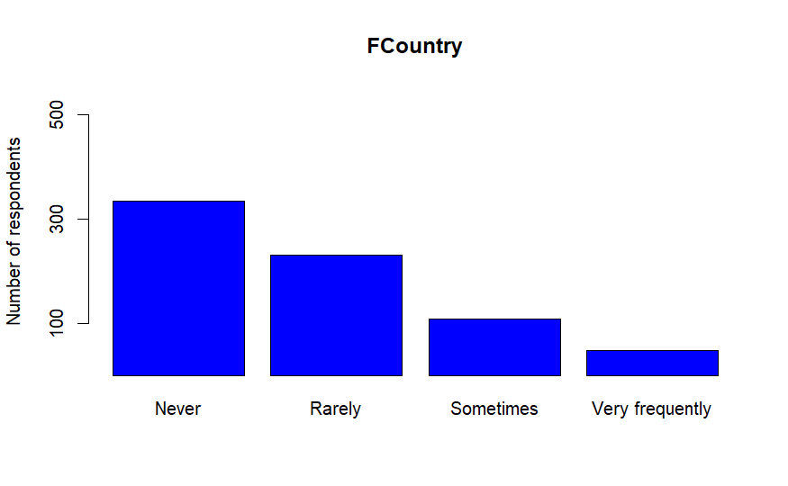

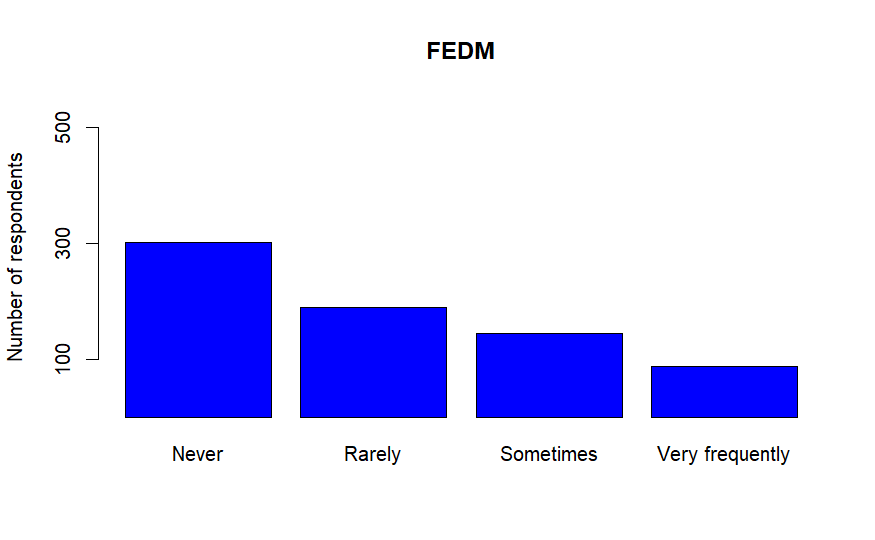

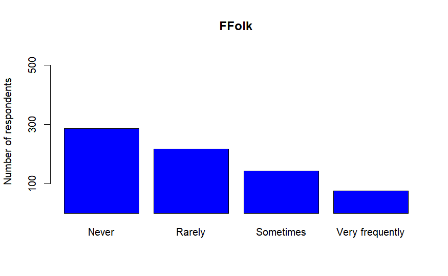

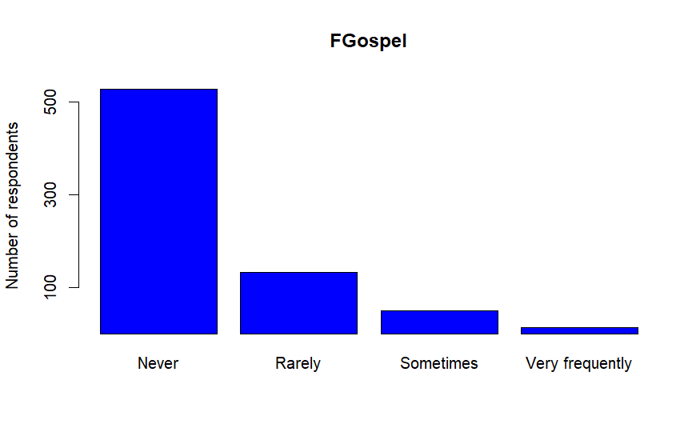

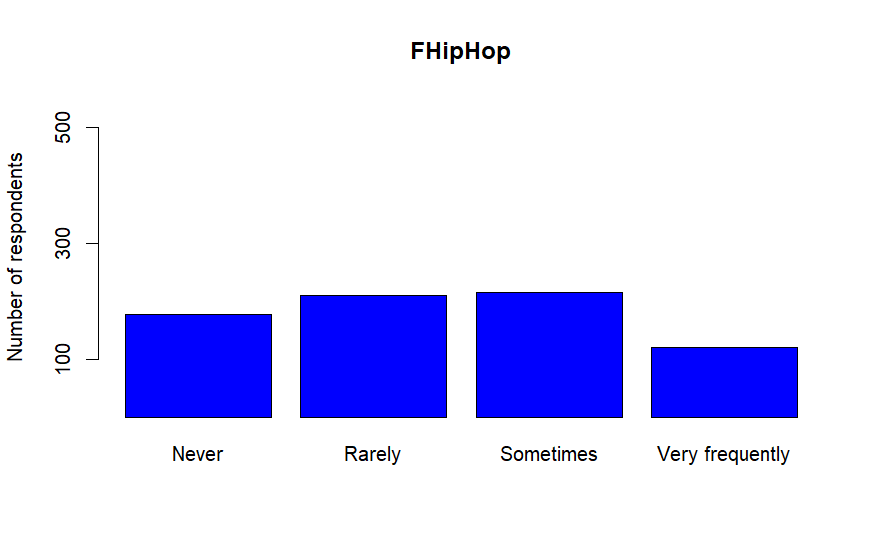

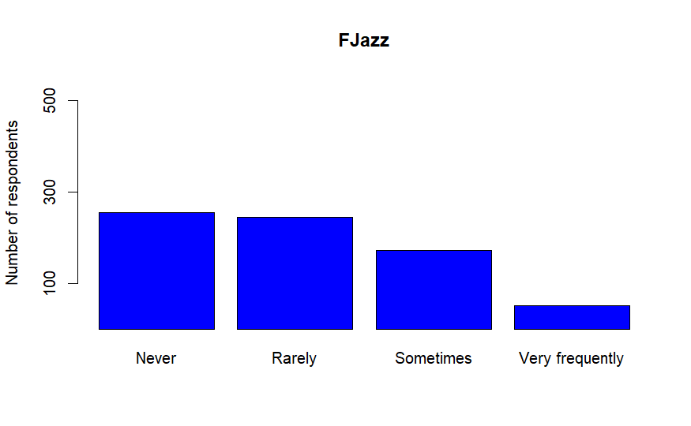

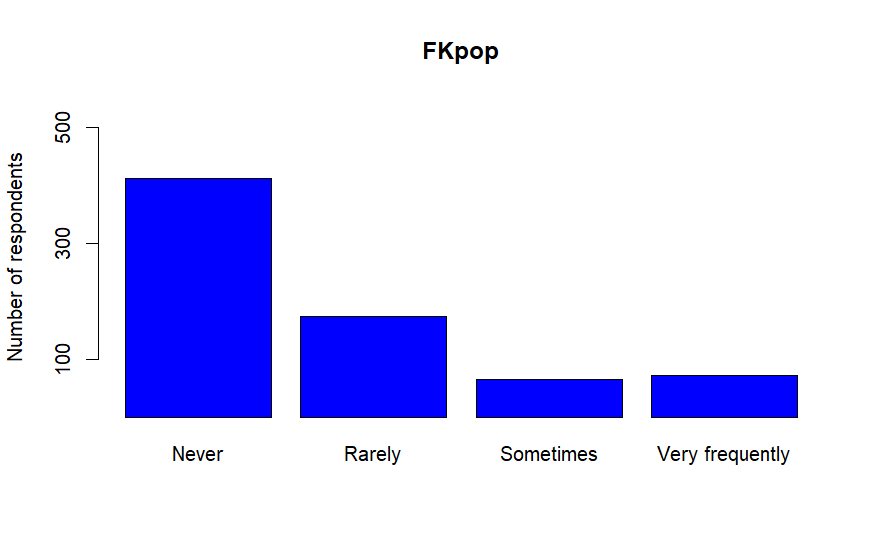

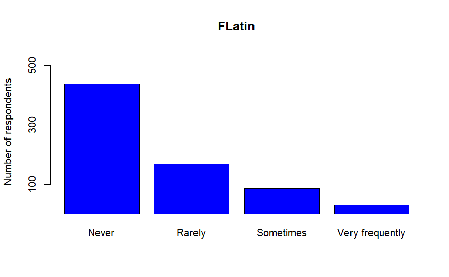

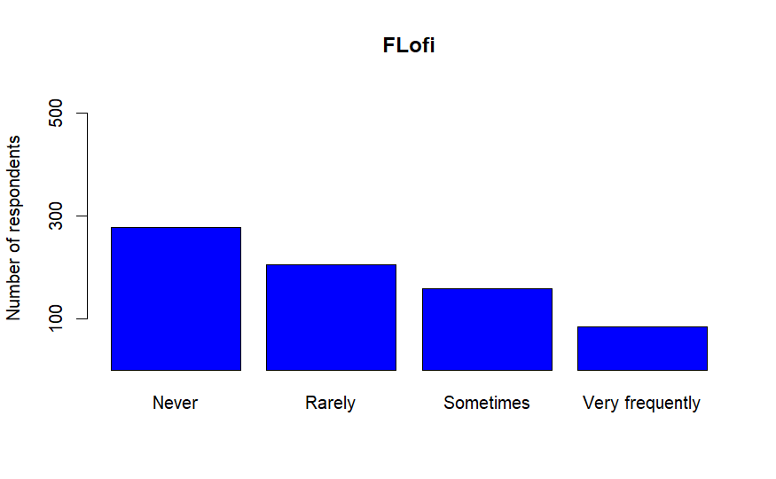

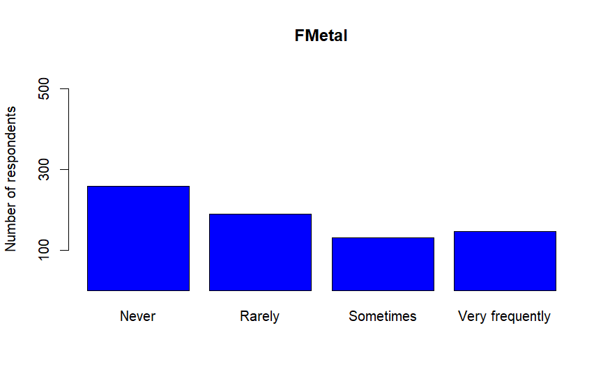

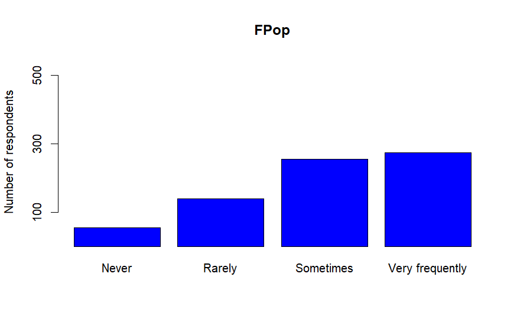

[4 more figures not shown]

The figure above displays how often people listen to each type of music.

```r
# Set the overall plot layout
par(mfrow=c(2, 2), mar=c(4, 4, 2, 1), oma=c(2, 2, 2, 2), cex.main=1.5)

# Plot histograms for each mental health condition
hist(df$Anxiety, main="Anxiety", yaxt="n", ylim=c(0, 100), xlab="Anxiety score")
axis(2, at=c(0, 100))
```

```r
hist(df$Depression, main="Depression", yaxt="n", ylim=c(0, 100), xlab="Depression score")
axis(2, at=c(0, 100))
```

```r
hist(df$Insomnia, main="Insomnia", yaxt="n", ylim=c(0, 250), xlab="Insomnia score")
axis(2, at=c(0, 200))
```

[figure not shown]

```r
hist(df$OCD, main="OCD", yaxt="n", ylim=c(0, 300), xlab="OCD score")
axis(2, at=c(0, 300))
```

LET’S GROUP THEM BY THEIR FAVORITE GENRE OF MUSIC

```r
names(df)
```

```
 [1] "Age"                       "Primary.streaming.service" "Hours.per.day"             "While.working"             "Instrumentalist"
 [6] "Composer"                  "Fav.genre"                 "Exploratory"               "Foreign.languages"         "FClassical"
[11] "FCountry"                  "FEDM"                      "FFolk"                     "FGospel"                   "FHipHop"
[16] "FJazz"                     "FKpop"                     "FLatin"                    "FLofi"                     "FMetal"
[21] "FPop"                      "FRnB"                      "FRap"                      "FRock"                     "FVGM"
[26] "Anxiety"                   "Depression"                "Insomnia"                  "OCD"                       "Music.effects"
[31] "Age_Group"
```

# Insomnia analysis:

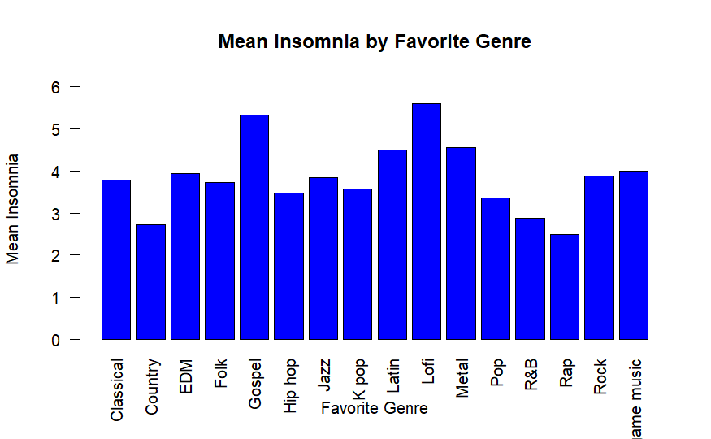

```r
# Charger la bibliothèque dplyr pour les opérations de manipulation de données
library(dplyr)
# Calculer la moyenne de l'insomnie pour chaque genre de musique
insomnia_music <- df %>%
  group_by(`Fav.genre`) %>%
  summarise(mean_insomnia = mean(Insomnia, na.rm = TRUE))

# Tracer un graphique à barres de la moyenne de l'insomnie pour chaque genre de musique
barplot(insomnia_music$mean_insomnia,
        names.arg = insomnia_music$`Fav.genre`,
        xlab = "Favorite Genre",
        ylab = "Mean Insomnia",
        main = "Mean Insomnia by Favorite Genre",
        col = "blue",
        border = "black",
        ylim = c(0, max(insomnia_music$mean_insomnia) * 1.1),
        las = 2 # Orientation du texte sur l'axe x (2 pour vertical)
        )
```

```r
NA
NA
```

# OCD analysis:

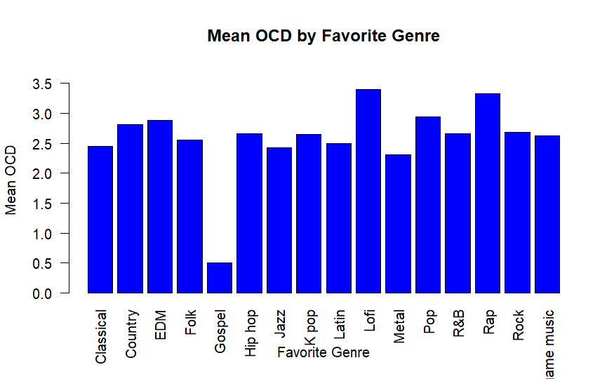

```r
# Calculer la moyenne de l'OCD pour chaque genre de musique
ocd_music <- df %>%
  group_by(`Fav.genre`) %>%
  summarise(mean_ocd = mean(OCD, na.rm = TRUE))

# Tracer un graphique à barres de la moyenne de l'OCD pour chaque genre de musique
barplot(ocd_music$mean_ocd,
        names.arg = ocd_music$`Fav.genre`,
        xlab = "Favorite Genre",
        ylab = "Mean OCD",
        main = "Mean OCD by Favorite Genre",
        col = "blue",
        border = "black",
        ylim = c(0, max(ocd_music$mean_ocd) * 1.1),
        las = 2 # Orientation du texte sur l'axe x (2 pour vertical)
        )
```

# Anxiety analysis

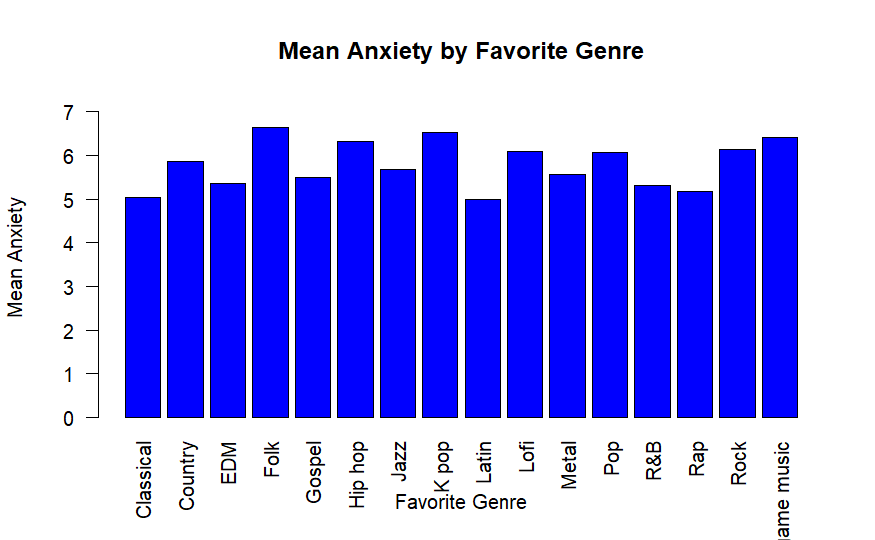

The figure above exhibits very similar levels of anxiety in all types of music

# Depression analysis

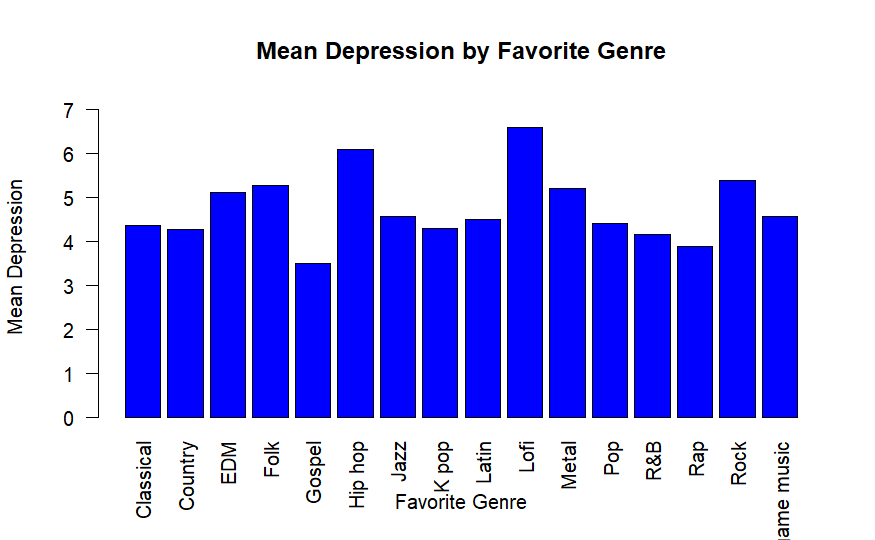

Again, Gospel and Rap music present the lowest depression rate while LOFI and HIP HOP tend to be depressing for most of people

# Relation between the 4 indicators of mental health ( OCD, Anxiety, Depression, Insomnia ) and the music effect

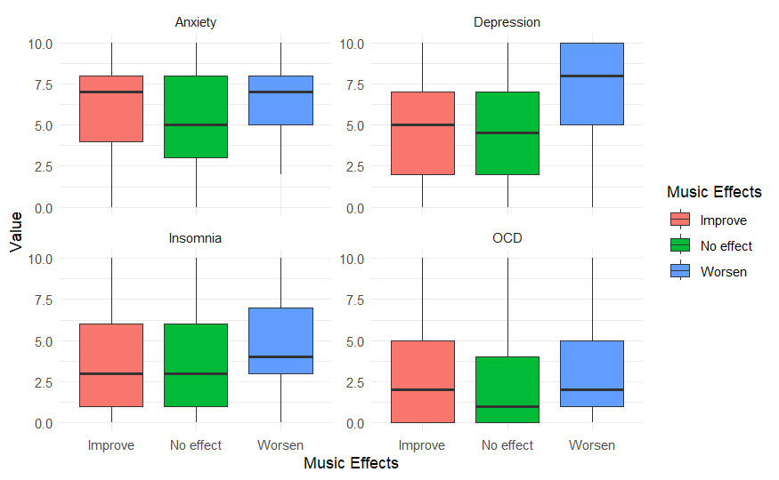

```r
library(ggplot2)

# Melting the dataframe to long format for easier plotting
library(tidyr)
df_long <- pivot_longer(df, cols = c(Anxiety, Depression, Insomnia, OCD),
                        names_to = "Measure", values_to = "Value")

# Plotting
ggplot(df_long, aes(x = Music.effects, y = Value, fill = Music.effects)) +
  geom_boxplot() +
  facet_wrap(~ Measure, scales = "free_y", nrow = 2) +
  labs(x = "Music Effects", y = "Value", fill = "Music Effects") +
  theme_minimal()
```

For depression and insomnia, it’s evident from the boxplots that individuals indicating “worsen” for the music effect exhibit higher levels of insomnia and depression.

The similarity of the boxplots for OCD and anxiety across different groups may indicate less variation in these variables among the “improve,” “no effect,” and “worsen” groups regarding the music effect. This suggests that OCD and anxiety may not be significant determining factors in predicting the music effect on individuals, at least in terms of observed variation in the data; let’s verify this observation.

The Kruskal-Wallis test is a non-parametric method used to compare the median values of three or more independent groups when the data violates the assumptions of parametric tests like ANOVA.

## Kruskal-Wallis

```r
# Charger la bibliothèque pour Kruskal-Wallis
library(ggpubr)
# Effectuer le test de Kruskal-Wallis pour la variable OCD
kruskal_test_OCD <- kruskal.test(Music.effects ~ OCD, data = df)
kruskal_test_OCD
```

```
    Kruskal-Wallis rank sum test

data:  Music.effects by OCD
Kruskal-Wallis chi-squared = 15.329, df = 12, p-value = 0.2239
```

```r
# Effectuer le test de Kruskal-Wallis pour la variable anxiety
kruskal_test_anxiety <- kruskal.test(Music.effects ~ Anxiety, data = df)
kruskal_test_anxiety
```

```
    Kruskal-Wallis rank sum test

data:  Music.effects by Anxiety
Kruskal-Wallis chi-squared = 16.879, df = 11, p-value = 0.1115
```

```r
# Effectuer le test de Kruskal-Wallis pour la variable anxiety
kruskal_test_depression <- kruskal.test(Music.effects ~ Depression, data = df)
kruskal_test_depression
```

```
    Kruskal-Wallis rank sum test

data:  Music.effects by Depression
Kruskal-Wallis chi-squared = 30.829, df = 11, p-value = 0.001173
```

The Kruskal-Wallis chi-squared value is 15.329. This suggests that, within the sample, there is some variation in “Music.effects” based on “OCD”.

Since the p-value (0.2239) is higher than the commonly chosen significance threshold of 0.05, we do not have enough evidence to reject the null hypothesis. Thus, we conclude that there is no significant difference between the means of the groups for the variable “Music.effects” based on the variable “OCD”.

In other words, the levels of “OCD” do not appear to have a significant impact on the perception of the music effect (“Music.effects”).

The same analysis holds true for anxiety. However, for depression, the p-value is <0.05, indicating that depression and the music effect are related.

#Classification with multiple classes for the target variable “Music.effects”

##Decision Tree

```r
# Load required packages
library(rpart)
library(caret)
# Set seed for reproducibility

# Split the data into training and testing sets
train_index <- createDataPartition(df$Music.effects, p = 0.8, list = FALSE)
train_data <- df[train_index, ]
test_data <- df[-train_index, ]

# Train the decision tree model on the training data
tree_model <- rpart(Music.effects ~ OCD + Anxiety + Depression + Insomnia, data = train_data, method = "class")

# Predict the Music.effect for the testing data
predicted_music_effect <- predict(tree_model, newdata = test_data, type = "class")

# Evaluate the performance of the model
confusion_matrix <- table(predicted_music_effect, test_data$Music.effect)
accuracy <- sum(diag(confusion_matrix)) / sum(confusion_matrix)

# Display the confusion matrix and accuracy
print(confusion_matrix)
```

```
predicted_music_effect Improve No effect Worsen
             Improve       105        31      3
             No effect       2         2      0
             Worsen          0         0      0
```

```r
print(paste("Accuracy:", accuracy))
```

```
[1] "Accuracy: 0.748251748251748"
```

La matrice de confusion que vous avez fournie montre que le modèle n’a prédit aucune observation “Worsen” pour les données de test. Cela indiquer plus probablement un déséquilibre de classe dans nos données.

Considérons d’autres mesures de performance, comme la précision, le rappel et le F1-score, qui prennent en compte le déséquilibre de classe.

```r
# Load required packages
library(rpart)
library(caret)

# Set seed for reproducibility
set.seed(123)

# Split the data into training and testing sets
train_index <- createDataPartition(df$Music.effects, p = 0.8, list = FALSE)
train_data <- df[train_index, ]
test_data <- df[-train_index, ]

# Train the decision tree model on the training data
tree_model <- rpart(Music.effects ~ OCD + Anxiety + Depression + Insomnia, data = train_data, method = "class")

# Predict the Music.effects for the testing data
predicted_music_effect <- predict(tree_model, newdata = test_data, type = "class")

# Convert predicted_music_effect to a factor with levels same as test_data$Music.effects
predicted_music_effect <- factor(predicted_music_effect, levels = levels(test_data$Music.effects))


# Evaluate the performance of the model
confusion_matrix <- confusionMatrix(predicted_music_effect, test_data$Music.effects)

# Display the confusion matrix
print(confusion_matrix)
```

```
Confusion Matrix and Statistics

           Reference
Prediction  Improve No effect Worsen
  Improve       105        31      3
  No effect       2         2      0
  Worsen          0         0      0

Overall Statistics

               Accuracy : 0.7483
                 95% CI : (0.6689, 0.817)
    No Information Rate : 0.7483
    P-Value [Acc > NIR] : 0.5446

                  Kappa : 0.0544

 Mcnemar's Test P-Value : NA

Statistics by Class:

                     Class: Improve Class: No effect
Sensitivity                 0.98131          0.06061
Specificity                 0.05556          0.98182
Pos Pred Value              0.75540          0.50000
Neg Pred Value              0.50000          0.77698
Prevalence                  0.74825          0.23077
Detection Rate              0.73427          0.01399
Detection Prevalence        0.97203          0.02797
Balanced Accuracy           0.51843          0.52121
                     Class: Worsen
Sensitivity                0.00000
Specificity                1.00000
Pos Pred Value                 NaN
Neg Pred Value             0.97902
Prevalence                 0.02098
Detection Rate             0.00000
Detection Prevalence       0.00000
Balanced Accuracy          0.50000
```

```r
# Calculate recall for each class
recall <- confusion_matrix$byClass["Sensitivity"]

# Calculate F1-score for each class
f1_score <- confusion_matrix$byClass["F1"]

# Display recall and F1-score
print(paste("Recall (Sensitivity):", recall))
```

```
[1] "Recall (Sensitivity): NA"
```

```r
print(paste("F1-score:", f1_score))
```

```
[1] "F1-score: NA"
```

D’aprés ces resultats, la sensibilité mesure la proportion de vrais positifs parmi tous les exemples positifs.

Pour la classe “Improve”, la sensibilité est de 98.13%, mais pour la classe “No effect”, elle est seulement de 6.06%. Cela indique que le modèle a du mal à détecter les exemples de la classe “No effect”

L aprévalence est la proportion d’observations dans l’ensemble de données. La prévalence de la classe “Improve” est de 74.83%, tandis que celle de la classe “No effect” est de 23.08% et celle de la classe “Worsen” est de 2.10%. Ceci fait référence au déséquilibre dans notre data set

```r
# Ensure Music.effects is a factor variable with correct levels
df$Music.effects <- factor(df$Music.effects)

# Load required packages
library(DMwR)


# Perform oversampling using SMOTE
oversampled_df <- SMOTE(Music.effects ~ ., data = df, perc.over = 5, k = 2)
```

## Random Forest with class weighting

```r
# Load required packages
library(randomForest)
library(caret)

# Set seed for reproducibility
set.seed(123)

# Ensure Music.effects is a factor variable with correct levels
df$Music.effects <- factor(df$Music.effects)

# Define class weights
# Create a vector to hold class weights
#class_weights <- ifelse(df$Music.effects == "Worsen", 5,1)
# Check the levels of Music.effects
levels(df$Music.effects)
```

```
[1] "Improve"   "No effect" "Worsen"
```

```r
# Check the class weights vector
table(class_weights)
```

[output not shown]

```r
# Split the data into training and testing sets
train_index <- createDataPartition(df$Music.effects, p = 0.8, list = FALSE)
train_data <- df[train_index, ]
test_data <- df[-train_index, ]


# Train the random forest model on the training data with class weights

rf_model <- randomForest(factor(Music.effects) ~ OCD + Anxiety + Depression + Insomnia,
                         data = train_data,
                         classwt = list(Improve = 1, `No effect` = 2, Worsen = 10))

levels(train_data$Music.effects)
```

```
[1] "Improve"   "No effect" "Worsen"
```

```r
levels(test_data$Music.effects)
```

```
[1] "Improve"   "No effect" "Worsen"
```

```r
# Predict the Music.effect for the testing data
predicted_music_effect <- predict(rf_model, newdata = test_data)

# Evaluate the performance of the model
confusion_matrix <- table(predicted_music_effect, test_data$Music.effect)
accuracy <- sum(diag(confusion_matrix)) / sum(confusion_matrix)

# Display the confusion matrix and accuracy
print(confusion_matrix)
```

```
predicted_music_effect Improve No effect Worsen
             Improve        94        28      2
             No effect      13         5      1
             Worsen          0         0      0
```

```r
print(paste("Accuracy:", accuracy))
```

```
[1] "Accuracy: 0.692307692307692"
```

## Multinomial Logistic Regression:

La régression logistique multinomiale est une méthode appropriée pour ce type de problème (prediction à 3 niveaux ) car elle permet de prédire une variable catégorielle avec plusieurs niveaux.

```r
# Load the nnet package for multinomial logistic regression
library(nnet)

# Convert the target variable to a factor if it's not already
df$Music.effects <- factor(df$Music.effects)

# Split the data into training and test sets
train_indices <- sample(1:nrow(df), 0.6 * nrow(df)) # 50% of the data for training
train_data <- df[train_indices, ]
test_data <- df[-train_indices, ]

# Define class weights
# Create a vector to hold class weights
class_weights <- ifelse(train_data$Music.effects == "Worsen", 5,
                        ifelse(train_data$Music.effects == "No effect", 2, 1))

# Train the multinomial logistic regression model with adjusted sample weights
model <- multinom(Music.effects ~ OCD + Insomnia + Depression + Anxiety,
                  data = train_data,
                  weights = class_weights)
# Make predictions on the test set
predictions <- predict(model, newdata = test_data, type = "class")

# Display the confusion matrix
confusion_matrix <- table(test_data$Music.effects, predictions)
print(confusion_matrix)
```

```
           predictions
            Improve No effect Worsen
  Improve       204        17      0
  No effect      51        12      0
  Worsen          6         0      0
```

```r
# Calculate the accuracy of the model
accuracy <- sum(diag(confusion_matrix)) / sum(confusion_matrix)
print(paste("Accuracy:", accuracy))
```

```
[1] "Accuracy: 0.744827586206897"
```

```r
# Calculate balanced accuracy
sensitivity <- diag(confusion_matrix) / rowSums(confusion_matrix)
balanced_accuracy <- mean(sensitivity)

# Calculate precision, recall, and F1-score
precision <- diag(confusion_matrix) / colSums(confusion_matrix)
recall <- sensitivity
f1_score <- 2 * (precision * recall) / (precision + recall)

# Print metrics
print(paste("Balanced Accuracy:", balanced_accuracy))
```

```
[1] "Balanced Accuracy: 0.371184371184371"
```

```r
print("Precision:")
```

```
[1] "Precision:"
```

```r
print(precision)
```

```
  Improve No effect    Worsen
0.7816092 0.4137931       NaN
```

```r
print("Recall (Sensitivity):")
```

```
[1] "Recall (Sensitivity):"
```

```r
print(recall)
```

```
  Improve No effect    Worsen
0.9230769 0.1904762 0.0000000
```

```r
print("F1-Score:")
```

```
[1] "F1-Score:"
```

```r
print(f1_score)
```

```
  Improve No effect    Worsen
0.8464730 0.2608696       NaN
```

```r
# Explore resampling techniques, adjust class weights, and feature engineering as needed
```

Malgré l’assignation des poids, l’analyse révèle des biais persistants dus au déséquilibre dans la répartition des classes au sein du jeu de données.

Le taux de précision équilibré, qui prend en compte la sensibilité (taux de vrais positifs) de chaque classe et les moyenne, est de 37,12%. Cette mesure offre une représentation plus précise de la performance du modèle, notamment dans les jeux de données déséquilibrés. Un taux de précision équilibré de 37,12% suggère que la performance du modèle est significativement affectée par le déséquilibre des classes.